# Adaptive ranges

How the tool decides whether a session or recovery score is normal for this player

Author

Michael Davies

Published

20 October 2026

The load monitoring tool has to answer one question quickly: is this session, or this recovery score, normal for this player? This report sets out how that is decided. Each value is compared with a range built from the player’s own history, which updates after every session. The method follows Roshan et al. (2021), adapted for one player. The worked example uses high-speed running and is calculated from the data when the report renders.

## Summary of decisions

| Decision | Choice |
| --- | --- |
| What gets a range | Each metric on each match-day label, independently |
| Recovery scores | Ranged like load, even though the provider already scores them against the player’s norm: the range adds the match week and a sense of scale |
| Starting point | Load: the 2022/23 baseline season. Recovery: August to December 2023 |
| Known changes | At each new season or new head coach, past sessions are cut to count as 10 sessions |
| Range width | 90% predictive interval |
| Scale | log(value + offset), with the offset set to 25% of the metric’s typical baseline session, so ranges work in ratios rather than fixed amounts; peak speed and recovery as recorded |
| Adaptive range or z-score | Adaptive range for flags, with a standardised score shown alongside |
| Minimum history | Load: always enough baseline sessions. Recovery: at least 5 baseline values |
| What isn’t ranged | Extended-gap days, match days outside 85 to 125 minutes, and the baseline period itself |

## The method

### Where it comes from

Roshan et al. (2021) compared ways of building adaptive reference ranges for people monitored over time. A static range compares everyone with the same limits; an adaptive range compares each person with their own history, so a value can be unusual for one person and normal for another. Their approach models each person’s typical value and variability, and flags a new value when it falls outside the range their next value would be expected to fall in: the predictive interval.

In the paper, each person’s typical value is also linked to a group average, so people with little data borrow strength from everyone else. With one player there is no group to borrow from, so this tool keeps the individual part of the method and replaces the group with the player’s own earlier data: a baseline period sets the starting point, and each session updates it.

### Step by step

Each unit (one metric on one match-day label, such as high-speed running on MD-2) is handled on its own.

1. **Starting point.** From the unit’s baseline sessions, take the mean (what’s typical), the variance (how much it normally varies), and the number of sessions, capped at 10. The cap sets how much the starting point counts, in sessions.
2. **Range for the next session.** The predictive range is the mean plus or minus a Student-*t* multiplier × the spread × √(1 + 1 / weight). With little evidence the multiplier and the √ term are large, so the range is wide; both shrink as sessions accumulate.
3. **Judge the session.** Above the range, below it, or in range. The session’s own value never affects its own range. The tool also shows a standardised score: how many predictive spreads the session sits from its typical value, read like a z-score.
4. **Update.** The session is added to the unit’s history with the standard normal-inverse-gamma update: the new mean is a weighted average of the old mean and the new value, and the spread absorbs how far the value was from what was expected. Only a few running quantities are needed: the typical value, the spread and the weight.
5. **Known changes.** When a new season starts or a new head coach arrives, the history’s weight is cut back to 10 sessions. The previous picture of normal is kept as the starting point, but the range widens and the new period’s sessions soon take over.

## Worked example: high-speed running

High-speed running (distance above 21 km/h) is the tool’s lead load measure. These are its ranges on MD-2 from 2023/24 onwards. Each point is a session; the band is the range the session was judged against, built only from earlier sessions.

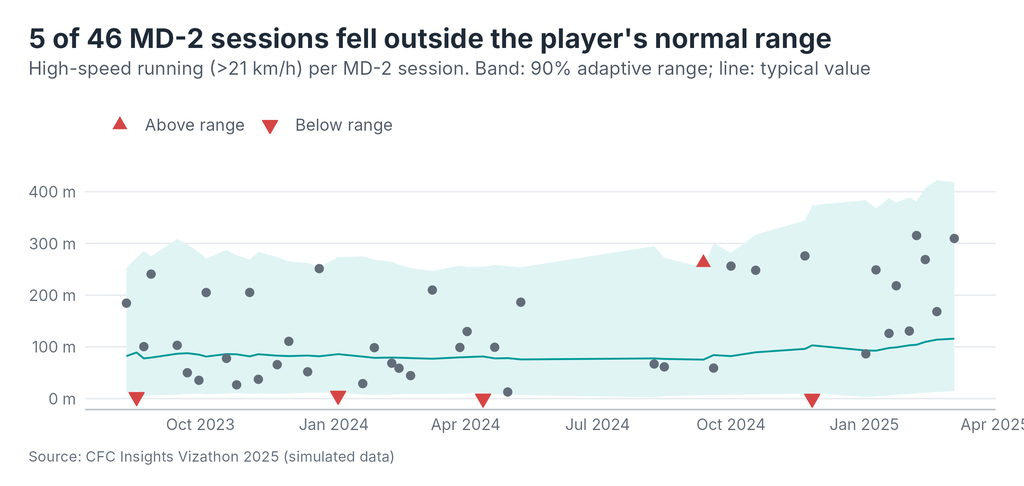

The band is not symmetric: it extends further above the typical value than below it, because the range is built on the log scale (see Scale). It also moves as the player’s sessions change, rather than staying fixed at the baseline.

Across all match-day labels, the share of high-speed running sessions flagged is close to what a 90% range should give, about one in ten. Labels with fewer sessions vary more around that rate:

| Label | Sessions | Above range | Below range | Flagged | Typical range width (m) |
| --- | --- | --- | --- | --- | --- |
| MD+1 | 50 | 0 | 0 | 0% | 343 |
| MD+2 | 55 | 5 | 2 | 13% | 405 |
| MD-5 | 16 | 1 | 2 | 19% | 572 |
| MD-4 | 23 | 0 | 3 | 13% | 678 |
| MD-3 | 27 | 4 | 0 | 15% | 585 |
| MD-2 | 46 | 1 | 4 | 11% | 267 |
| MD-1 | 94 | 3 | 8 | 12% | 309 |
| MD | 30 | 0 | 2 | 7% | 856 |

Overall, 10% of 341 assessed sessions were flagged.

## Decisions

### What gets a range

**Decision.** Each metric on each match-day label gets its own range, calculated independently.

**Options considered.** Independent ranges; partial pooling, where each label’s range borrows strength from the player’s other days, as the paper does across people.

**Why.** Each day of the match week has a different training objective, so an MD-1 session should not be pulled towards what is typical on MD-4. Borrowing strength between labels would blur exactly the differences the tool needs to see.

**Consequence.** Labels with few sessions, such as MD-5, start with wide ranges and narrow over time instead of borrowing precision from other days.

### Recovery scores: already relative to the norm

**The question.** The recovery scores arrive already expressed relative to the player’s own norm: 0% is normal for that player and -20% is 20% below it. If the provider has already said how far from normal each score is, what does a range add?

**Decision.** Recovery scores get ranges in the same way as load: by match-day label, learned from the player’s own history. The two steps answer different questions:

| Step | Question it answers |
| --- | --- |
| Provider’s score | How does today compare with the player’s overall norm? |
| Adaptive range | Is that difference unusual for this player on this kind of day? |

**Why.** The provider’s score turns raw measurements, such as questionnaire answers, blood results and joint range tests, into one value on a common ruler. It stops there. It does not say how far from 0 is unusual, and it uses the same 0 on every day of the match week. The range treats the provider’s percentage as a number like any other, just as it treats total distance, and learns where this player’s scores usually sit on each label and how much they vary. That adds two things:

1. **The match week.** Scores dip after a match and recover through the week, so the same score means different things on different days. Judged against 0 alone, almost every MD+1 would look like a problem.
2. **A sense of scale.** How far from 0 is unusual differs by marker. Soreness varies about 2.3 times as much as the overall score, so a fixed cut-off on the percentage would flag one far more often than the other.

| Score | MD+1 | MD+2 | MD-5 | MD-4 | MD-3 | MD-2 | MD-1 | MD |
| --- | --- | --- | --- | --- | --- | --- | --- | --- |
| Overall recovery score | -8% | -5% | +5% | +2% | -1% | +0% | +0% | -1% |
| Subjective recovery | -10% | -7% | +12% | +6% | +1% | +3% | +3% | -2% |
| Muscle soreness | -19% | -13% | -6% | +1% | -4% | -4% | -5% | +8% |
| Sleep quality | -22% | -12% | -1% | -6% | -12% | -9% | -2% | +1% |

The table shows the average score on each label for the four markers collected most days. The worked example below uses the latest range on each label for subjective recovery, with the same score of -20% on two different days:

| Label | Provider says | Usual on this label | Normal range | Range says |
| --- | --- | --- | --- | --- |
| MD+1 | 20% below the player's norm | -10% | -32% to +12% | In range: normal for this day |
| MD-4 | 20% below the player's norm | +6% | -17% to +28% | Below range: unexpected on this day |

**When a range would add little.** If the provider’s norm already allowed for the match week and for each marker’s spread, fixed cut-offs on the percentage would do the same job more simply.

**Consequence.** Because the range keeps learning, a slow, lasting change becomes the player’s new usual and stops being flagged, whereas a fixed 0 would keep showing it. Blood markers averaged -5% in 2023/2024 and -18% in 2024/2025. The data guide does not say how the provider sets its norm, so both may be adapting at once. This matters most for the markers collected about once a week (blood markers, joint range and load tolerance), whose purpose is to catch slow change and which have few values on each label. It is listed under Limitations.

### Starting point

**Decision.** Load ranges start from the full 2022/23 season. Recovery data begins in July 2023, but the July pre-season scores are removed (see the data quality report), so recovery ranges start from August to December 2023. The baseline periods set the starting point and are not flagged themselves. The reasoning for both periods is in the feature engineering report.

### Known changes: seasons and managers

**Decision.** Season starts and head-coach changes are recorded as known events (`input/reference/events.csv`). At each one, the weight of a unit’s history is cut to 10 sessions. Between events, every session counts fully and the history grows. When events coincide, the strongest cut applies.

**Options considered.** Let all history count fully; use a rolling window, such as the last 20 sessions; down-weight older sessions continuously; cut the history’s weight at known changes, and by how much.

**Why.** Training changes when the season or the coach changes: this player’s data covers five head coaches. A new coach brings a different way of training, so sessions in the first weeks look unusual against the old picture of normal. Those flags describe the coach’s sessions, not the player, so the range should widen when a change is known. A full manager-by-day model, with separate ranges for each coach, is not possible with one player: Frank Lampard had 11 matches, so some combinations would have two or three sessions. Cutting the weight at a known change is the standard alternative in Bayesian monitoring, an intervention: the method does not claim to know how the change alters training, only that its confidence in “normal” should drop. Continuous down-weighting of older sessions was not needed: between events, the history only ever covers one season under one coach.

The two head-coach changes after the baseline fall on the same days as season starts (1 July 2023 and 1 July 2024), so in this data the events act together. The two changes inside the 2022/23 baseline are recorded but have no effect, because the baseline is summarised as a whole. How strong the cut should be:

| Metric | Cut to | Flagged | Above / below | First 5 sessions of a season | Rest of the season |
| --- | --- | --- | --- | --- | --- |
| High-speed running | 20 sessions | 10.9% | 4.4% / 6.5% | 11.2% | 10.7% |
| High-speed running | 10 sessions (chosen) | 10.3% | 4.1% / 6.2% | 11.2% | 10.0% |
| High-speed running | 5 sessions | 8.2% | 2.6% / 5.6% | 8.7% | 8.0% |
| Total distance | 20 sessions | 12.0% | 5.9% / 6.2% | 23.7% | 8.4% |
| Total distance | 10 sessions (chosen) | 10.3% | 4.7% / 5.6% | 20.0% | 7.3% |
| Total distance | 5 sessions | 8.2% | 4.1% / 4.1% | 11.2% | 7.3% |

A cut to 10 sessions brings both lead metrics closest to one session in ten flagged and trims the extra flags at the start of a season. Cutting to 5 removes the early excess for total distance but leaves ranges too wide for too long, so fewer than one in ten sessions are flagged overall.

**Consequence.** One rule covers both kinds of change, and adding another, such as a return from a long injury, is one row in the events file. A season without a new coach is treated the same way as one with: pre-season changes fitness and training too.

### Range width

**Decision.** 90% predictive intervals.

**Options considered.** 90% or 95%.

**Why.** A 95% range flags about one session in twenty, which suits an alarm. The tool is for monitoring: staff want to see sessions worth a second look, and a 90% range flags about one in ten.

**Consequence.** Flags are a prompt to look, not a warning. The app describes them as “outside the usual range for this day”, not as a risk.

### Adaptive range or z-score

**Decision.** Flags come from the adaptive range. The app also shows a standardised score, (value − typical value) ÷ predictive spread, which reads like a z-score.

**Options considered.** A z-score against past sessions of the same label, using all previous sessions or only the last 20; the adaptive range.

**Why.** A z-score treats the past mean and standard deviation as exactly known. With 10 to 20 past sessions they are only estimates, so a cut-off meant to flag one session in ten flags more, and most of the extra flags come early in each season when the evidence is thinnest. A z-score over all history also never forgets old seasons, so after training changes, sessions keep looking unusual. The adaptive range allows for both. Roshan et al. note that a z-score corrected for estimating the mean and spread follows a Student-*t* distribution: the adaptive range is that corrected z-score, plus a starting point and a cap on old history.

| Metric | Method | Flagged | First 5 sessions of a season | Rest of the season | Same flag as adaptive |
| --- | --- | --- | --- | --- | --- |
| High-speed running | Adaptive range | 10.3% | 11% | 10% |  |
| High-speed running | z-score, all history | 17.0% | 20% | 16% | 93.3% |
| High-speed running | z-score, last 20 sessions | 15.2% | 19% | 14% | 93.8% |
| Total distance | Adaptive range | 10.3% | 20% | 7% |  |
| Total distance | z-score, all history | 18.2% | 29% | 15% | 90.9% |
| Total distance | z-score, last 20 sessions | 13.8% | 25% | 10% | 95.9% |

### Scale

**Decision.** Load metrics are modelled as log(value + offset), where the offset is 25% of the metric’s typical (median) session in the baseline season. Peak speed and the recovery scores are modelled as recorded. Each metric’s offset is stored in the GPS glossary (`log_offset`), so it is visible and can be changed.

**Options considered.** No transform; log(value + 1); log(value + offset) with an offset scaled to each metric.

**Why a transform is needed.** The range is a Student-*t* interval: a typical value plus or minus a multiple of the spread. That assumes values scatter symmetrically around the typical value, by about the same amount whatever the typical value is. Load metrics break both assumptions:

- **They are bounded at zero and skewed to the right.** A session can sit far above the typical value but never far below it, because it cannot go below zero.
- **Their variation is proportional, not fixed.** A day that typically produces 500 m of high-speed running varies by hundreds of metres; a day that typically produces 100 m varies by tens.

On the raw scale, a symmetric range puts its lower limit near or below zero, so low sessions can almost never be flagged, while the long right tail produces too many flags above.

**Why a log.** On the log scale, differences become ratios: 200 m against 100 m is the same step as 400 m against 200 m. “Double the usual” then means the same thing on every day and for every metric, which is how practitioners already describe load (“30% above normal”). The spread becomes roughly symmetric and stable, which is what the interval needs, and when the range is converted back to real units it is asymmetric, reaching further above the typical value than below it and never below zero.

**Why an offset, and why not 1.** A log needs an offset because some sessions record zero distance in a speed band, and log(0) is undefined. The size of the offset also matters: it sets where the scale stops treating differences as proportional. Below the offset, differences behave roughly as fixed amounts; above it, as ratios. With an offset of 1, 5 m and 10 m of high-speed running look as far apart as 100 m and 200 m, so the many near-zero training sessions inflated the spread, ranges became very wide on the upper side, and almost only near-zero sessions were flagged. An offset in proportion to the metric’s own scale keeps the log’s benefit without that distortion.

**Why 25% of the typical session.** Tying the offset to each metric’s typical baseline session makes one rule work for metres, counts and minutes alike. The 25% is a calibrated choice rather than a derived one. A 90% range should flag about one session in ten, split evenly between above and below. Across the metrics, 25% kept the overall rate close to one in ten while giving the most even split; smaller offsets flag slightly fewer sessions, but more of them below the range, which is the near-zero problem returning. For the two lead metrics:

| Metric | Scale | Flagged | Above / below |
| --- | --- | --- | --- |
| High-speed running | As recorded | 12.3% | 12.0% / 0.3% |
| High-speed running | log(value + 1) | 7.6% | 1.2% / 6.5% |
| High-speed running | log(value + 37), chosen | 10.3% | 4.1% / 6.2% |
| Total distance | As recorded | 11.4% | 8.2% / 3.2% |
| Total distance | log(value + 1) | 9.1% | 3.5% / 5.6% |
| Total distance | log(value + 1100), chosen | 10.3% | 4.7% / 5.6% |

With the chosen offsets, every load metric flags close to the intended rate:

| Metric | Scale | Sessions | Flagged | Above / below |
| --- | --- | --- | --- | --- |
| Total distance | log(value + 1100) | 341 | 10.3% | 4.7% / 5.6% |
| High-speed running (>21 km/h) | log(value + 37) | 341 | 10.3% | 4.1% / 6.2% |
| Very high-speed running (>24 km/h) | log(value + 14) | 341 | 10.6% | 6.2% / 4.4% |
| Sprint distance (>27 km/h) | log(value + 4.5) | 341 | 8.2% | 4.1% / 4.1% |
| Accelerations and decelerations (>2.5 m/s²) | log(value + 22) | 341 | 10.3% | 3.8% / 6.5% |
| Accelerations and decelerations (>3.5 m/s²) | log(value + 6.7) | 341 | 10.3% | 5.6% / 4.7% |
| Accelerations and decelerations (>4.5 m/s²) | log(value + 1.8) | 341 | 8.8% | 4.4% / 4.4% |
| Session duration | log(value + 16) | 341 | 10.9% | 4.4% / 6.5% |
| Peak speed | As recorded | 341 | 5.6% | 1.8% / 3.8% |
| Time in HR zone 1 (50–60% max HR) | log(value + 1.3) | 341 | 9.7% | 5.0% / 4.7% |
| Time in HR zone 2 (60–70% max HR) | log(value + 4) | 341 | 10.0% | 1.8% / 8.2% |
| Time in HR zone 3 (70–80% max HR) | log(value + 4) | 341 | 10.0% | 2.9% / 7.0% |
| Time in HR zone 4 (80–90% max HR) | log(value + 1.7) | 341 | 8.5% | 4.1% / 4.4% |
| Time in HR zone 5 (90–100% max HR) | log(value + 0.012) | 341 | 8.8% | 7.0% / 1.8% |
| Time in the yellow HR zone (50–80% max HR) | log(value + 9.8) | 341 | 10.0% | 3.2% / 6.7% |
| Time in the red HR zone (80–100% max HR) | log(value + 1.8) | 341 | 7.3% | 3.8% / 3.5% |
| Distance per minute | log(value + 16) | 291 | 11.0% | 6.5% / 4.5% |
| High-speed running (>21 km/h) per minute | log(value + 0.47) | 291 | 12.0% | 5.2% / 6.9% |
| Very high-speed running (>24 km/h) per minute | log(value + 0.16) | 291 | 9.3% | 4.1% / 5.2% |
| Sprint distance (>27 km/h) per minute | log(value + 0.05) | 291 | 7.2% | 3.1% / 4.1% |
| Accelerations and decelerations (>2.5 m/s²) per minute | log(value + 0.32) | 291 | 8.6% | 3.4% / 5.2% |
| Accelerations and decelerations (>3.5 m/s²) per minute | log(value + 0.093) | 291 | 8.9% | 4.5% / 4.5% |
| Accelerations and decelerations (>4.5 m/s²) per minute | log(value + 0.024) | 291 | 8.2% | 4.1% / 4.1% |

| Metric | 10% | 25% (chosen) | 50% |
| --- | --- | --- | --- |
| Total distance | 9.4% | 10.3% | 11.1% |
| High-speed running (>21 km/h) | 8.2% | 10.3% | 10.0% |
| Very high-speed running (>24 km/h) | 7.9% | 10.6% | 10.9% |
| Sprint distance (>27 km/h) | 9.7% | 8.2% | 8.8% |
| Accelerations and decelerations (>2.5 m/s²) | 9.7% | 10.3% | 12.0% |
| Accelerations and decelerations (>3.5 m/s²) | 9.7% | 10.3% | 10.9% |
| Accelerations and decelerations (>4.5 m/s²) | 7.9% | 8.8% | 9.4% |
| Session duration | 10.9% | 10.9% | 12.3% |
| Time in HR zone 1 (50–60% max HR) | 10.0% | 9.7% | 9.4% |
| Time in HR zone 2 (60–70% max HR) | 10.3% | 10.0% | 10.3% |
| Time in HR zone 3 (70–80% max HR) | 9.1% | 10.0% | 10.0% |
| Time in HR zone 4 (80–90% max HR) | 7.6% | 8.5% | 9.1% |
| Time in HR zone 5 (90–100% max HR) | 9.4% | 8.8% | 10.6% |
| Time in the yellow HR zone (50–80% max HR) | 9.1% | 10.0% | 10.6% |
| Time in the red HR zone (80–100% max HR) | 8.2% | 7.3% | 9.1% |
| Distance per minute | 11.7% | 11.0% | 11.0% |
| High-speed running (>21 km/h) per minute | 10.7% | 12.0% | 12.7% |
| Very high-speed running (>24 km/h) per minute | 8.2% | 9.3% | 9.3% |
| Sprint distance (>27 km/h) per minute | 8.9% | 7.2% | 7.2% |
| Accelerations and decelerations (>2.5 m/s²) per minute | 8.2% | 8.6% | 9.6% |
| Accelerations and decelerations (>3.5 m/s²) per minute | 8.2% | 8.9% | 9.6% |
| Accelerations and decelerations (>4.5 m/s²) per minute | 6.5% | 8.2% | 8.6% |

**Alternatives not taken.** A Box-Cox transform would let the data choose the shape of the curve for each metric, and a skewed distribution such as the log-normal or gamma could be modelled directly. Both are more complex to explain and to maintain. The log with an offset keeps the conjugate update, so each range follows from a few running quantities and stays fast and transparent.

**Per-minute values are transformed too.** They are rates rather than amounts, but they are still bounded at zero and right-skewed. Modelled as recorded, high-speed running per minute was flagged almost only above its range (10.7% above, 0.3% below); on the log scale the split is balanced. They use the same 25% rule for their offsets.

**What is not transformed.** Peak speed is close to symmetric already. The recovery composites are already expressed relative to the player’s norm and can be negative, so a log would not make sense.

**Consequence.** The line in the worked example is the typical session, not the arithmetic average: converting a mean on the log scale back to real units gives a value close to the median, which sits below the average for skewed data. For monitoring that is the more useful reference, and the app labels it “typical”. Ranges for log-scale metrics reach further above the typical value than below it. Peak speed flags less than the intended rate, mostly below the range: it is capped by how fast the player can run, so sessions rarely exceed the usual range.

### Minimum history

**Decision.** Recovery ranges need at least 5 baseline values on a label; below that, the tool shows “building baseline”. Load needs no minimum, because every label has at least 9 baseline sessions.

**Why.** The method can produce a range from very few values, but with fewer than 5 the range is so wide that it would rarely flag anything, and showing it would suggest a judgement the data cannot support.

### What isn’t ranged

**Decision.** Extended-gap days (pre-season, international breaks, the end of a season), match days lasting less than 85 or more than 125 minutes, and the baseline periods are not judged against a range.

**Why.** Extended-gap sessions have no consistent purpose to compare against. On match days, load depends on how long the player played, so only full matches (85 to 125 minutes) make a usable reference; shorter and longer match days are compared with a full match as a percentage instead. The choice of band is explained in the feature engineering report. The baseline periods are what the starting point is built from, so judging them against it would be circular.

## Limitations

- **One player.** The hierarchical part of the paper’s method, borrowing strength across people, needs more than one player. Every table carries a player ID, so it can be added if squad data becomes available.
- **Normality on the modelling scale.** The method assumes values are roughly normal after the log transform. Strongly bimodal metrics, such as sprint distance on days with and without sprint work, will fit less well.
- **Recovery scores are judged twice.** The provider has already compared each recovery score with the player’s norm, and the range then learns what is usual from those scores. A slow, lasting change can be absorbed into “usual” and stop being flagged (see Recovery scores).
- **Simulated data.** The flag rates above show the method behaving as designed, not that it detects anything real about this player.

## Reference

Roshan, D., Ferguson, J., Pedlar, C. R., Simpkin, A., Wyns, W., Sullivan, F. and Newell, J. (2021). A comparison of methods to generate adaptive reference ranges in longitudinal monitoring. *PLOS ONE*, 16(2), e0247338. https://doi.org/10.1371/journal.pone.0247338

Data: CFC Insights Vizathon 2025, Chelsea FC Performance Insights (simulated data for one player). Raw files are downloaded from the public competition repository, not stored here, and loaded into the project’s DuckDB database before this report runs.